```python
import numpy as np
import matplotlib.pyplot as plt
```

# Problem 1: Variability of Neural Traces

Functions required for simulating a network of neurons

ode_step returns the values of f(x,t) or dx/dt given all the parameters of the model larry_model solves the forward equation for a given time duration based on the parameters that we input to this function

```python
from scipy.integrate import solve_ivp
from functools import partial

def ode_step(t, x, g, J, I, R0, Rmax, tau):

    phi = np.zeros(x.shape)
    phi[x<=0] = R0*np.tanh(x[x<=0]/R0)
    phi[x>0]  = (Rmax-R0)*np.tanh(x[x>0]/(Rmax-R0))

    r    = R0 + phi

    dxdt = 1/tau*(-x + g*(J@r) + I[:, int(np.floor(t-1e-5))])

    return dxdt





def larry_model(parameters):
    ## Parameters

    N     = parameters['N']
    tau   = parameters['tau']*parameters['fs']
    T     = parameters['T']*parameters['fs']
    g     = parameters['g']
    J     = parameters['J']
    inp   = parameters['inp']
    Rmax  = parameters['Rmax']
    R0    = parameters['R0']
    inp_t = parameters['inp_t']
    spon  = parameters['spon']*parameters['fs']



    ## Input current

    I_zero              = np.zeros((N,T))
    I_step              = np.tile(np.concatenate((np.zeros((1, spon)), inp*np.ones((1, T - spon))),axis=1), (N,1))
    I_const             = inp*np.ones((N, T))


    if inp_t is 'zero':
        I = I_zero
    elif inp_t is 'const':
        I = I_const
    elif inp_t is 'step':
        I = I_step


    ## Initialize

    x0      = np.random.rand(N, 1)


    ## Solving equations
    sol = solve_ivp(partial(ode_step,g=g,J=J,I=I,R0=R0,Rmax=Rmax,tau=tau),[0,T],x0.squeeze())


    x         = sol.y
    t         = sol.t
    phi       = np.zeros(x.shape)
    phi[x<=0] = R0*np.tanh(x[x<=0]/R0)
    phi[x>0]  = (Rmax-R0)*np.tanh(x[x>0]/(Rmax-R0))

    r         = (R0 + phi).T

    t = t / parameters['fs']

    return r, t, I
```

A default parameter setting, depending on each problem we will change some of these parameters

```python
parameters = {}

parameters['N']     = 1000    # number of neurons
parameters['tau']   = 0.01    # time constant (seconds)
parameters['T']     = 2       # full duration (seconds)
parameters['g']     = 1.5     # controls the variance of connections
parameters['Rmax']  = 2       # R_max
parameters['R0']    = 0.1*parameters['Rmax'] # R_0
parameters['inp_t'] = 'const'  # type of input
parameters['inp_h'] = 1        # I_{1/2}
parameters['inp']   = 3.5;     # amount of input step current
parameters['J']     = np.random.normal(loc=0.0, scale=1/np.sqrt(parameters['N']), size=(parameters['N'], parameters['N'])) # connection matrix
parameters['fs']    = 1000     # sampling frequency
parameters['spon']  = 1;       # (seconds)
```

## 1a) Computing the I*{1/2} by plotting the average value of r/R*{Rmax} for a range of inputs.

```
[-5 -4 -3 -2 -1  0  1  2  3  4  5  6  7  8  9 10 11 12 13 14 15 16 17 18
 19]
[0.01236008 0.01267538 0.01330694 0.01401637 0.01706623 0.22139876
 0.45059055 0.65663563 0.75582599 0.8260941  0.88272636 0.91721532
 0.94940883 0.96147686 0.96663958 0.9703894  0.97208126 0.97000298
 0.97256135 0.97313558 0.97396796 0.97272661 0.97266939 0.97301357
 0.97227358]
```

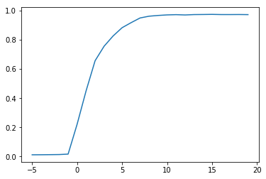

```python
parameters['inp_t'] = 'const'

inp_range = np.arange(-5,20,1)
mean_r = np.zeros(inp_range.shape)
for i in range(len(inp_range)):
    parameters['inp'] = inp_range[i]
    parameters['J']   = np.random.normal(loc=0.0, scale=1/np.sqrt(parameters['N']), size=(parameters['N'], parameters['N'])) # connection matrix
    r, t, I = larry_model(parameters)
    mean_r[i] = r.mean()/parameters['Rmax']

plt.plot(inp_range, mean_r)
print(inp_range)
print(mean_r)


# Therefore inp_h is ~ 1

parameters['inp_h'] = 1
```